# Assignment 1 Able.com Case

Author

Sebastian Perez Parra

Published

August 24, 2025

We start by loading the necessary libraries and the datasets.

```r
library(tidyverse)
```

```r
toy_sales <- read_csv("https://raw.githubusercontent.com/jefftwebb/data/main/toy_sales_data.csv")
toy_sales_PO <- read_csv("https://raw.githubusercontent.com/jefftwebb/data/main/toy_sales_PO.csv")
```

# Q1

We calculate the true ATE using the potential outcomes.

```r
# code annotations go within the chunks

true_ATE = mean(toy_sales_PO$y1 - toy_sales_PO$y0) %>% round(2)
print(paste("- The true ATE using the potential outcomes is", true_ATE))
```

```
[1] "- The true ATE using the potential outcomes is 45.9"
```

- This means that average treatment effect is 45.9 more toys sold than the control group.

# Q2

Now, we estimate the ATE using the observed outcomes.

```r
est_ATE = round(mean(toy_sales$weekly_amount_sold[toy_sales$is_on_sale == TRUE]) -
mean(toy_sales$weekly_amount_sold[toy_sales$is_on_sale == FALSE]),2)
print(paste("- The estimated ATE using the observed outcomes is", est_ATE))
```

```
[1] "- The estimated ATE using the observed outcomes is 77.96"
```

- This means that the estimated average treatment effect is 77.96 toys sold than the control group, 32.06 more than the true ATE.

# Q3

- The bias in using the observed data is that we may not be considering a confounding variable which may be palying a role in the weekly amount sold.

# Q4

```r
toy_sales %>%
  group_by(is_on_sale) %>%
  summarise(mean_size = mean(avg_week_sales),
            sd_size = sd(avg_week_sales),
            n = n())
```

```
# A tibble: 2 × 4
  is_on_sale mean_size sd_size     n
       <dbl>     <dbl>   <dbl> <int>
1          0      18.8    3.72   976
2          1      21.6    4.99  1024
```

- The mean difference (although with a standard deviation which can make them also be considered similar) between the treatment and control group (is on sale or not) is notable. This means that the groups are not exchangeable and that company size may be a potential confounder.

# Q5

We run a linear regression model with weekly_amount_sold and is_on_sale.

```r
lm(weekly_amount_sold ~ is_on_sale + avg_week_sales, data = toy_sales)
```

```
Call:
lm(formula = weekly_amount_sold ~ is_on_sale + avg_week_sales,
    data = toy_sales)

Coefficients:
   (Intercept)      is_on_sale  avg_week_sales
         2.929          69.009           3.189
```

- The adjusted ATE is 69.01 which is 23.11 higher than the true ATE. This is better estimate than the estimated ATE (using the observed outcomes).

# Q6

We calculate the true CATE of a sales campaign conditional on weeks to Christmas.

```r
true_CATE <- toy_sales_PO %>% group_by(weeks_to_xmas) %>% summarise(CATE = round(mean(y1 - y0), 2))

print(true_CATE)
```

```
# A tibble: 4 × 2
  weeks_to_xmas  CATE
          <dbl> <dbl>
1             0  38.8
2             1  46.1
3             2  48.9
4             3  49.8
```

- The CATE numbers represent (as it’s name suggests) the average treatment effect **conditioned** on weeks to Christmas.

# Q7

We run a linear regression model with weekly_amount_sold, is_on_sale and an interaction term between is_on_sale and weeks_to_xmas.

```r
model = lm(weekly_amount_sold ~ is_on_sale * weeks_to_xmas + avg_week_sales, data = toy_sales)
```

We now estimate the CATE using the regression model above.

```r
print(paste("- Effect when weeks_to_xmas is 0:",32.635 + 6.968 * 0))
```

[output not shown]

```r
print(paste("- Effect when weeks_to_xmas is 1:",32.635 + 6.968 * 1))
```

[output not shown]

```r
print(paste("- Effect when weeks_to_xmas is 2:",32.635 + 6.968 * 2))
```

[output not shown]

```r
print(paste("- Effect when weeks_to_xmas is 3:",32.635 + 6.968 * 3))
```

[output not shown]

- The CATE numbers represent the average treatment effect **conditioned** on weeks to Christmas using the interaction model.

**Challenge:** To know plot and view the result, we begin by creating a dataset with the estimated values.

```r
(new_data <- expand.grid(avg_week_sales = mean(toy_sales$avg_week_sales), # used the mean
                               is_on_sale = 0:1,       # used the integers corresponding to the range of the data
                               weeks_to_xmas = c(0, 1, 2, 3)))
```

```
  avg_week_sales is_on_sale weeks_to_xmas
1       20.21436          0             0
2       20.21436          1             0
3       20.21436          0             1
4       20.21436          1             1
5       20.21436          0             2
6       20.21436          1             2
7       20.21436          0             3
8       20.21436          1             3
```

We make predictions with the values.

```r
new_data$preds <- predict(model, newdata = new_data)

new_data
```

```
  avg_week_sales is_on_sale weeks_to_xmas     preds
1       20.21436          0             0  26.70180
2       20.21436          1             0  64.48906
3       20.21436          0             1  58.95883
4       20.21436          1             1 106.26025
5       20.21436          0             2  91.21586
6       20.21436          1             2 148.03145
7       20.21436          0             3 123.47289
8       20.21436          1             3 189.80264
```

To finally plot the results.

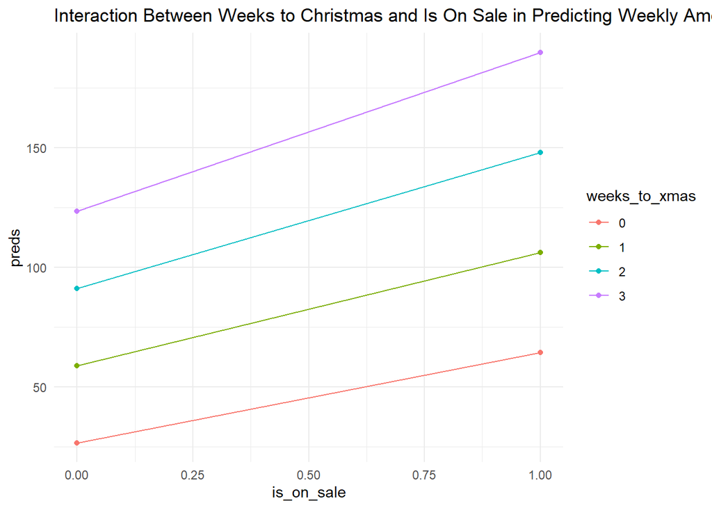

```r
new_data |>
  mutate(weeks_to_xmas = factor(weeks_to_xmas)) |> # turned this into a factor for plotting convenience
  ggplot(aes(is_on_sale, preds, col = weeks_to_xmas, group = weeks_to_xmas)) +
  geom_point() +
  geom_line() +
  theme_minimal() +
  ggtitle("Interaction Between Weeks to Christmas and Is On Sale in Predicting Weekly Amount Sold")
```